# Candor Corpus Analyses

Jamie Reilly, Ginny Ulichney, Ben Sacks

September 2023

We will be analyzing alignment across six dimensions as functions of age and age differences between speakers engaged in unscripted dyads: valence; trust; arousal; concreteness; word length (letters); word frequency (lg). Load dat from public github respository called reillylab_data.

# Prep summary data

Creates summary dataframes collapsing across exchanges so that each dyad has one score for each dimension by unique combinations of participant and dyad (since one participant could have particpated in more than one dyad)

```
## 'data.frame':    18048 obs. of  4 variables:
##  $ event_id  : Factor w/ 1504 levels "0020a0c5-1658-4747-99c1-2839e736b481",..: 1 1 1 1 1 1 1 1 1 1 ...
##  $ dimension : Factor w/ 6 levels "aff_trust","aff_valence",..: 1 1 2 2 3 3 4 4 5 5 ...
##  $ who_older : Factor w/ 2 levels "older","younger": 1 2 1 2 1 2 1 2 1 2 ...
##  $ meanRating: num  3.57 3.67 6.8 7.1 4.88 ...
```

# Data Visualization

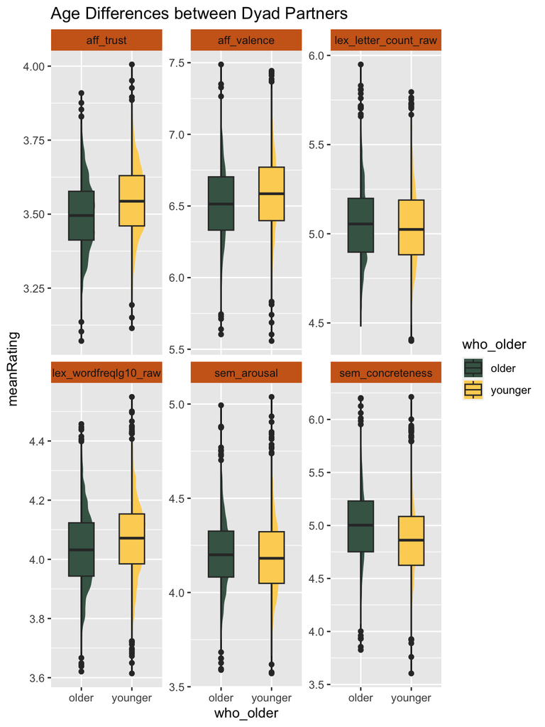

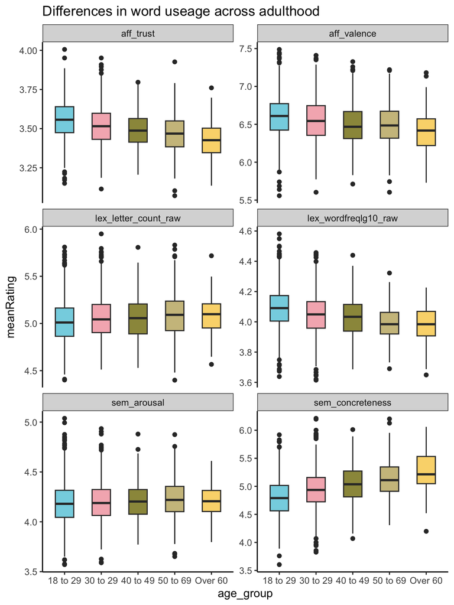

# Descriptives - NEW

summary statistics

Unique (#)

Missing (%)

Mean

SD

Min

Median

Max

aff_trust

3078

0

3.5

0.1

3.1

3.5

4.0

aff_valence

3078

0

6.5

0.3

5.6

6.6

7.5

lex_letter_count_raw

3078

0

5.1

0.2

4.4

5.0

5.9

[figure not shown]

lex_wordfreqlg10_raw

3078

0

4.1

0.1

3.6

4.1

4.6

sem_arousal

3078

0

4.2

0.2

3.6

4.2

5.0

[figure not shown]

sem_concreteness

3078

0

4.9

0.4

3.6

4.9

6.2

[figure not shown]

# Contrast 1: Main effects of aging and age differences on word usage

Contrast differences between who is older in each dyad for all six dimensions Filter the original dataframe to exclude any speaker or dyad where there is no age reported for one or both speakers. Dimensions are:  
aff_trust  
aff_valence  
lex_letter_count_raw  
lex_wordfreqlg10_raws  
em_arousal  
sem_concreteness

## ttests on who_older by dimension

Uses dataframe where there are only age differences (not 0 or NA) between speakers in dyad

[output not shown]

This runs on everyone with an age (i.e., everyone left in the data after filtering); grouped by event_id and speaker name.

# CONTRAST II:

## AUC ~ Age-Differences

co-varied for sex, race, edu differences; first run scatterplot and examine linearity beteen AUC and age_diff – group by dimension and event_id

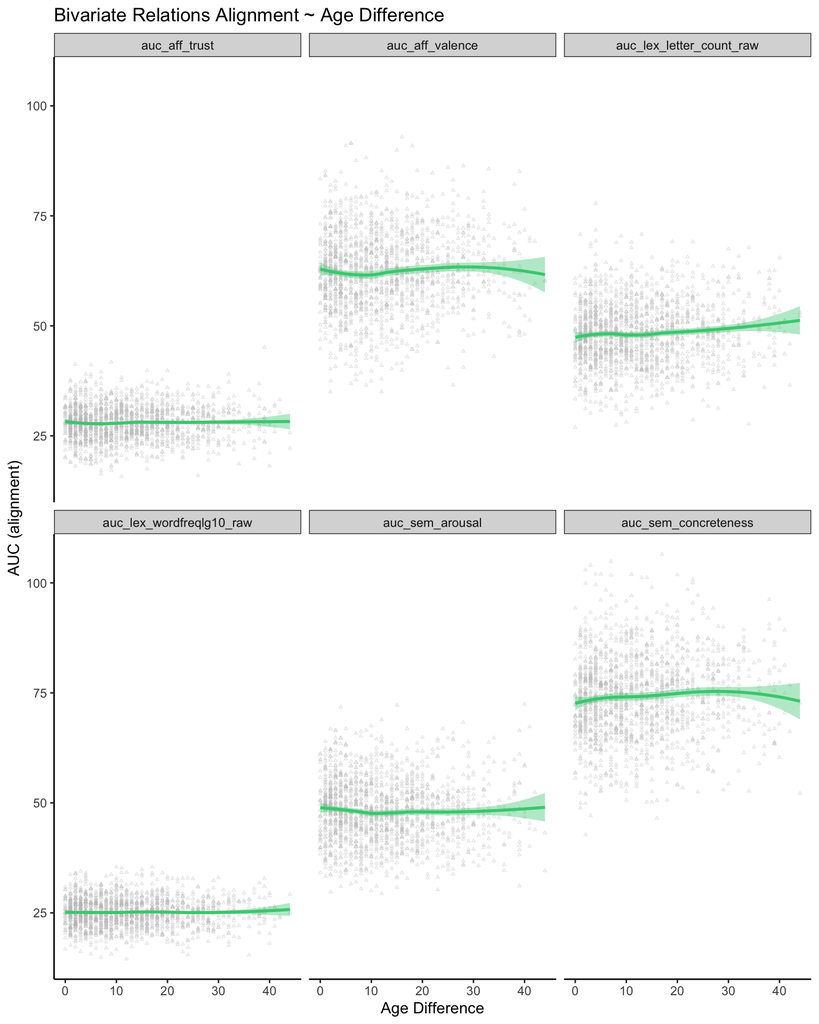

## Real vs. Random Dyad AUC contrasts

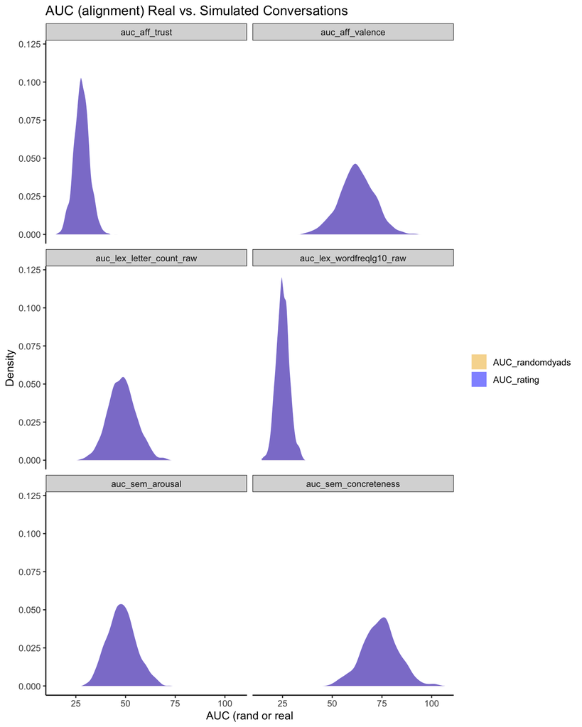

```r
auc_fake <- aucspear %>%
    pivot_longer(1:6, names_to = "dimension", values_to = "AUC_randomdyads") %>%
    data.frame()
auc_fake_sumDAT <- auc_fake %>%
    select(dimension, event_id, AUC_randomdyads) %>%
    group_by(dimension, event_id) %>%
    dplyr::summarize_at("AUC_randomdyads", mean) %>%
    data.frame()
auc_fake_sumDAT$dimension <- as.factor(auc_fake_sumDAT$dimension)
auc_Both <- full_join(auc_sumDAT, auc_fake_sumDAT, by = c("dimension", "event_id"))
auc_Both$dimension <- as.factor(auc_Both$dimension)
auc_Both <- auc_Both %>%
    pivot_longer(cols = c("AUC_rating", "AUC_randomdyads"), names_to = "which_auc",
        values_to = "AUC") %>%
    data.frame()
auc_Both$which_auc <- as.factor(auc_Both$which_auc)
# Density plats AUC random to structured
col.vec <- c("goldenrod2", "blue")
auc_plots <- ggplot(auc_Both, aes(x = AUC, fill = which_auc)) + geom_density(alpha = 0.5,
    colour = "white") + scale_fill_manual(values = col.vec) + xlab("AUC (rand or real") +
    ylab("Density") + jamie.theme + ggtitle("AUC (alignment) Real vs. Simulated Conversations") +
    facet_wrap(~dimension, ncol = 2)
print(auc_plots)
```

### Organize data

Select variables of interest, mean center independent variables for modeling

```r
# joining covariates to wide df
covars <- SumDat_All %>%
    dplyr::select(c("event_id", "speaker_names_raw", "edu_diff", "sex_diff", "race_diff")) %>%
    distinct()
auc_lme_df <- left_join(auc_sumDAT, covars, by = c("event_id"))

# mean center continuous independent vars
auc_lme_df$age_diff <- as.vector(scale(auc_lme_df$age_diff, center = T, scale = F))
auc_lme_df$edu_diff <- as.vector(scale(auc_lme_df$edu_diff, center = T, scale = F))

# create dfs by dimension
trust_df <- subset(auc_lme_df, dimension == "auc_aff_trust")
val_df <- subset(auc_lme_df, dimension == "auc_aff_valence")
nletter_df <- subset(auc_lme_df, dimension == "auc_lex_letter_count_raw")
wordfreq_df <- subset(auc_lme_df, dimension == "auc_lex_wordfreqlg10_raw")
arousal_df <- subset(auc_lme_df, dimension == "auc_sem_arousal")
concrete_df <- subset(auc_lme_df, dimension == "auc_sem_concreteness")

######### archived- manual way to get wide df of main effects for lme ##
######### SumDat_All_wide <- SumDat_All %>% dplyr::select(-c('.groups')) %>%
######### pivot_wider(id_cols = c('speaker_names_raw', 'event_id', 'age',
######### 'age_group', 'age_diff', 'race', 'race_diff', 'sex', 'sex_diff',
######### 'edu_yrs', 'edu_diff'), names_from = c('dimension'), values_from =
######### c('meanRating')) %>% dplyr::group_by(event_id) %>%
######### dplyr::mutate(speaker = row_number()) %>% ungroup() %>%
######### pivot_wider(id_cols = c('speaker_names_raw', 'event_id', 'age_diff',
######### 'race_diff','sex_diff','edu_diff'), names_from = c('dimension'),
######### values_from = c('meanRating'))
```

### Concreteness AUC ~ age diff

| ICC_adjusted | ICC_unadjusted | optional |
| --- | --- | --- |
| 0.11 | 0.11 | FALSE |

```
##
## Call:
## lm(formula = AUC_rating ~ age_diff + sex_diff + edu_diff + race_diff,
##     data = concrete_df)
##
## Residuals:
##     Min      1Q  Median      3Q     Max
## -30.177  -6.017   0.130   5.605  32.502
##
## Coefficients:
##             Estimate Std. Error t value Pr(>|t|)
## (Intercept) 74.63307    0.29696 251.327  < 2e-16 ***
## age_diff     0.06349    0.01740   3.649 0.000268 ***
## sex_diff1   -0.56568    0.33663  -1.680 0.092971 .
## edu_diff     0.05383    0.09361   0.575 0.565337
## race_diff0  -0.32739    0.33822  -0.968 0.333127
## ---
## Signif. codes:  0 '***' 0.001 '**' 0.01 '*' 0.05 '.' 0.1 ' ' 1
##
## Residual standard error: 9.327 on 3073 degrees of freedom
## Multiple R-squared:  0.005877,   Adjusted R-squared:  0.004583
## F-statistic: 4.542 on 4 and 3073 DF,  p-value: 0.001169
```

```
##                   2.5 %      97.5 %
## (Intercept) 74.05081791 75.21532371
## age_diff     0.02937686  0.09760872
## sex_diff1   -1.22571615  0.09435103
## edu_diff    -0.12972480  0.23738008
## race_diff0  -0.99055720  0.33576953
```

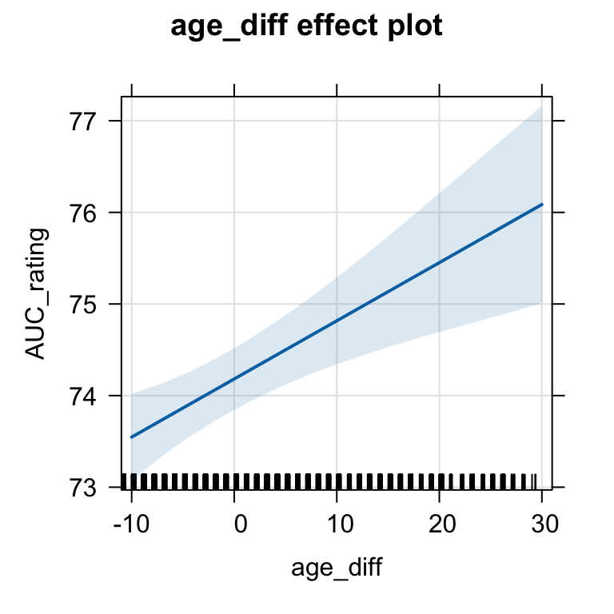

### Trust AUC ~ age diff

| ICC_adjusted | ICC_unadjusted | optional |
| --- | --- | --- |
| 0.11 | 0.11 | FALSE |

```
##
## Call:
## lm(formula = AUC_rating ~ age_diff + sex_diff + edu_diff + race_diff,
##     data = trust_df)
##
## Residuals:
##     Min      1Q  Median      3Q     Max
## -12.168  -2.573  -0.067   2.519  16.672
##
## Coefficients:
##              Estimate Std. Error t value Pr(>|t|)
## (Intercept) 27.921770   0.126414 220.876   <2e-16 ***
## age_diff     0.007136   0.007407   0.963    0.335
## sex_diff1    0.100705   0.143301   0.703    0.482
## edu_diff     0.063070   0.039851   1.583    0.114
## race_diff0  -0.011508   0.143980  -0.080    0.936
## ---
## Signif. codes:  0 '***' 0.001 '**' 0.01 '*' 0.05 '.' 0.1 ' ' 1
##
## Residual standard error: 3.97 on 3073 degrees of freedom
## Multiple R-squared:  0.00142,    Adjusted R-squared:  0.0001203
## F-statistic: 1.093 on 4 and 3073 DF,  p-value: 0.3584
```

```
##                    2.5 %      97.5 %
## (Intercept) 27.673905706 28.16963349
## age_diff    -0.007387288  0.02165888
## sex_diff1   -0.180269727  0.38168022
## edu_diff    -0.015068380  0.14120743
## race_diff0  -0.293814854  0.27079977
```

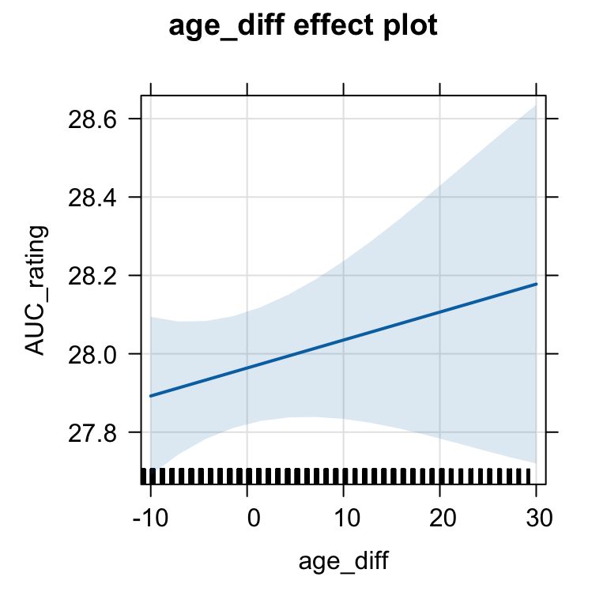